# Applied Quantitative Methods - Workshop Series

### Working with APIs

What is an API? API stands for “Application Programming Interface”, which is a way to let you talk to a 3rd-party application, usually either to retrieve data or update that application. Here is a good overview of [APIs](http://money.howstuffworks.com/business-communications/how-to-leverage-an-api-for-conferencing1.htm).

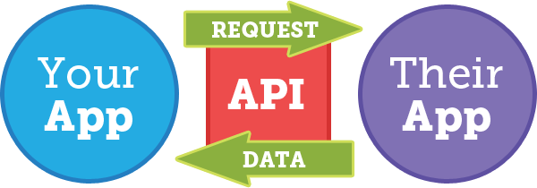

There are a few APIs in particular we will be examining that already have been integrated into R:

1. [rOpenSci](http://ropensci.org/): A plethora of R API packages from a variety of sources (Biological, Climate, etc.)
2. [Quandl](https://www.quandl.com/help/r): Follow the instructions, as you will need to register for an account and obtain an “access token”.
3. [Quantmod](http://www.quantmod.com/): We are quite familiar with this package so far, but check out the other sources you can call (Federal Reserve Economic Data(FED), Yahoo, Google, Oanda, etc.)
4. A [list](http://stats.stackexchange.com/questions/12670/data-apis-feeds-available-as-packages-in-r) of various APIs (Twitter, Amazon, Bloomberg, ect.)
5. My WorldBank API (update this when I’m done!)

### Group Project Outline - Due March 18th

You have formed groups of three. If you are not yet in a group, please notify us by email so we can find a place for you.

**Outline:**

1. **Create an objective**. An example could be to find, analyse and interpret data regarding specific variables and their effect on the corporate bankruptcy rates. Discuss with your group and choose something that you find interesting.
2. **Retrieve the Data**. Use a combination of the API sources introduced and other sources (web scraping, manual efforts, etc.) to gather the data of interest.
3. **Clean the Data**. Cleaning the data is a big task. You will likely have missing values, data sets of different dimensions, and similar country data with different country names (Dom. Rep. vs Dominican Republic). You will likely need to use [Stack Overflow](http://stackoverflow.com/) and Google as a first resource, but please as questions if you’re stuck!
4. **Wrangle the Data**. Use `dplyr`, `plyr` and your piping commands to get the results you need. Also look into the package [tidyr](http://blog.rstudio.org/2014/07/22/introducing-tidyr/) - trust me, it will become a usefult tool. Turn your data into the form you need for the task at hand!
5. **Visualise**. Use `ggplot2` to create visualisations of your data. Use visualisations to support your tables and results along the way.
6. **Present your Conclusion**. After your have fully analysed your results and have come up with information regarding your objective, state a clear and concise conclusion. Is there anything interesting that you would like to research further if you had more time?

**Expectations:**

- This is a group project == teamwork and collaboration outside of the workshop time.
- You will write a final team Markdown report including:
  - Introduction of your topic of research
  - All code including the data cleaning process and packages used
  - A thorough analysis and interpretation of results and process you took to reach your results (analysing the data in different ways while making use of `dplyr`, etc)
  - Visualisations
  - Conclusion of your results and further possibilities
  - Remarks stating the difficulties you faced and how you solved them
- Each team member will push the final version of the Markdown report to their own repo. In addition, a printed copy will be handed in on Wednesday March 18th (Knit PDF in Markdown).
- There will be a 15 minute presentation of your project. Please use [R Presentation](https://support.rstudio.com/hc/en-us/articles/200486468-Authoring-R-Presentations) to compile your slides (works just like markdown, and run your code within the slides!) Here’s a visial [example](http://slidify.org/samples/intro/#1) with a custom theme.
- **Make use of [R Markdown chunk options](http://rmarkdown.rstudio.com/authoring_rcodechunks.html). I really don’t want pages of code output that is ugly and doesn’t belong (or add value) to the report.**

[Report Example](https://github.com/Dustin21/Dustin21.github.io/blob/master/AQM/Week11_API/Example.pdf?raw=true): This is an example (old homework assignment of mine) of how I expect your report would look like. It is also a guide to data cleaning, web scraping and intro use to the WorldBank API. [Here’s another Example](http://kieranhealy.org/files/misc/pandoc-template-rmd-output-sample.png) (without the code of course).

**Pretend I do not know the material and coding you’re using. Cater the report to me as if you were teaching me about your process and results throughout (a walk-through).**

#### Group Projects

1. Group 1 - Vinicius, Jeffrey, Berk: [presentation](https://github.com/Dustin21/Dustin21.github.io/raw/master/AQM/group_projects/AQM.pdf), [report](https://github.com/Dustin21/Dustin21.github.io/raw/master/AQM/group_projects/AQM.Tourism.GDP.pdf), [repository](https://github.com/AQM-WorkshopRepo/Jeffrey_Li_AQM/blob/master/Country_GDP_v._Tourism_Expenditure.md)
2. Group 2 - Michael, Izell, Claudia: [presentation](https://github.com/Dustin21/Dustin21.github.io/raw/master/AQM/group_projects/AQM%20Presentation.pptx)

### Joins and Merges in SQL and R

Let’s say you have been working on your group project and have pulled out some interesting data from various sources that you would like to combine into a single data.frame that you can wrangle and visualise. You suddenly realise that all your data have different dimensions and some unneeded variables. This is when joins and merges come in! There are many ways to join and merge, and they are explained below:

In the following, x represents one data frame that you are attempting to combine in some way or form with another data.frame object y. Check out the [full documentation](http://www.rdocumentation.org/packages/dplyr) here.

- inner_join(x, y): return all rows from x where there are matching values in y, and all columns from x and y. If there are multiple matches between x and y, all combination of the matches are returned
- semi_join(x, y): return all rows from x where there are matching values in y, keeping just columns from x. A semi join differs from an inner join because an inner join will return one row of x for each matching row of y, where a semi join will never duplicate rows of x.
- left_join(x, y): return all rows from x, and all columns from x and y. If there are multiple matches between x and y, all combination of the matches are returned
- anti_join(x, y): return all rows from x where there are not matching values in y, keeping just columns from x
- merge(x, y): Merge two data frames by common columns or row names, or do other versions of database join operations

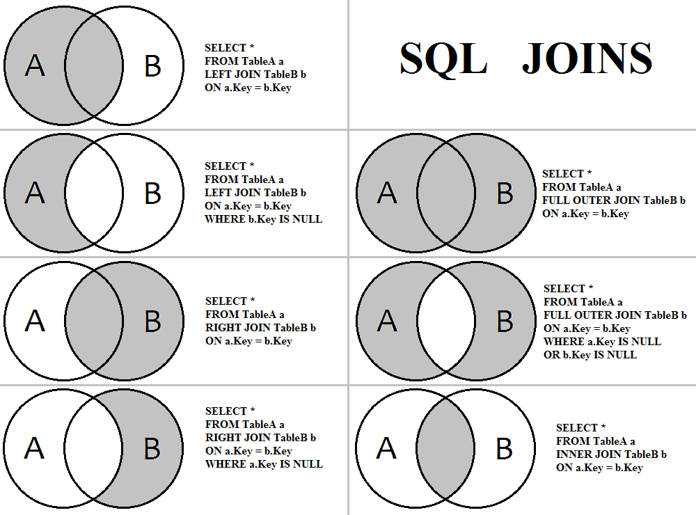

### Logistic Regression

Today’s slides: [Dharu’s](https://github.com/Dustin21/Dustin21.github.io/blob/master/AQM/Week12_logit/Logistic%20Regression%20Dharu.pdf?raw=true), [Haihan’s](https://github.com/Dustin21/Dustin21.github.io/blob/master/AQM/Week12_logit/Logistic%20Regression.pptx?raw=true)

#### Application to Global Security Markets and the EMH

**Research Paper we will be reviewing**: EMH_paper.pdf

**Slides**: EMH_slides.pdf

**Data**: index_dat.csv

**R Source**: EMH_mod.R

For the next workshop, please do the following:

1. Set up the confusion matrix for the logistic regression. That is, the matrix showing the number of correct vs incorrect predictions.
2. Determine the classification rate, as well as the error rate.
3. Instead of reusing the training data, check your results with cross-validation (CV).
   - Set up a cross-validation loop (or find a black-box function in R)
   - Set up the confusion matrix corresponding to the cross-validated predictions
   - Determine the CV classification rate and error rate
   - Do the results coincide with the paper? How do the CV results differ from the fit on the training set? Is this meaningful?
4. State your conclusion relating to the hypothesis mentioned in class (check slides)
5. Redo the above for a “short”, as apposed to the “long” as presented in the paper. Just read through the paper, and it will tell you exactly how they tested for this, then follow the same procedure that you did for the long.

### Intro to Time Series

**R Source:** earnings_forecast.R

**Data:** [earnings_data.csv](https://raw.githubusercontent.com/Dustin21/Dustin21.github.io/master/AQM/Week14_TimeSeries/earnings.csv)

When it comes to time, we are limited to the data retrieved at that precise moment. It is for this reason that time series is *deterministic*, and we must use alternative methods for uncovering patterns. For the short time we have to delve into the topic, we will learn about trends, seasonality, stationarity and some simple transformations. The real interesting part is modelling the not-so-trivial part - the error. Time series decomposition will be the main focus, and we will motivate some topics in dealing with autocorrelated error (ARIMA, etc.). The topics will be time permitting.

#### Autocorrelation (the correlogram):

Your task:

1. Retrieve a the adjusted closing price of a stock of your choice from the `quantmod` package using `getSymbols()`.
2. Transform the vector of prices into returns.
3. Construct a matrix with each column corresponding to an additional lag of the returns vector. For instance, the second column would be the lag one of the first column of returns, the third column would be lag two of the first column, and so on.
4. Remove or `filter()` the `NA` values, as these are not needed.
5. Examine the correlation matrix of the matrix above by calling the object in the function `cor()`. What seems to be happening as we look at the correlation of the lags of this time series? Do they increase? Diminish?
6. Call your single return vector with the function `acf()`, which will output something called a correllogram. We can easily obtain the autocorrelation matrix over a series of lags from this function and also analyse the correlogram which plots the acf in an intuitive manner. Does this reinforce what you discovered in 5? Does the stock follow a “random walk”?

There is much we can talk about regarding the autocorrelation (acf) and partial autocorrelation (pacf) functions. We can use these to spot non-stationarity such as trends and seasonaility, as well as to uncover the structure of ARIMA process to model the error, which is the most important aspect. Here’s a [resource on ARIMA](http://sfb649.wiwi.hu-berlin.de/fedc_homepage/xplore/tutorials/xegbohtmlnode39.html) to fuel your interest.

### Neural Networks

Alas, we have arrived at a learning technique. Neural networks have captured interest in recent years due to improvements in computational efficiency, which has allowed these networks to be optimised (the original issue that slowed their development). We will be introducing Neural networks with a programming language called Python.

Slides: NeuralNets.pdf

Python source: *in the slides*

#### Assignment:

Read over and understand the Prime Number sieve algorithm that was covered this week in Python, then re-implement the algorithm in R. The Python code is provided in the slides on slide 10. All you must do is transfer it to R syntax and get it running in R. Cross-check to make sure both implementations give you the same results. Upload your R code up to your repo by next week.